# bài 5 - Bài tập 2

Nguyễn Quốc Bảo

2025-03-14

**Bài tập 5**. Xét dữ liệu sau về tuổi thọ (lifetimes) của 14 khớp nối bánh răng (gear coupling)

#### Khởi tạo dữ liệu và dữ liệu censor với 0 là bị che khuất và 1 là không che khuất.

```r
# Thời gian
data_lifetime <- c(6.94, 5.50, 4.54, 2.14, 3.65, 3.40, 4.38,
                  10.24, 4.56, 9.24, 4.55, 4.15, 6.04, 10.23)
# Trạng thái (1 = uncensored, 0 = censored)
delta <- c(0, 1, 1, 1, 0, 0, 0,
           1, 1, 1, 0, 0, 1, 0)
data <- data.frame(data_lifetime, delta)
data
```

| data_lifetime | delta |
| --- | --- |
| 6.94 | 0 |
| 5.50 | 1 |
| 4.54 | 1 |
| 2.14 | 1 |
| 3.65 | 0 |
| 3.40 | 0 |
| 4.38 | 0 |
| 10.24 | 1 |
| 4.56 | 1 |
| 9.24 | 1 |

[output cut: 4 more lines]

#### a) Xác định hàm $Q(θ|θ^{(t)})$ bằng phương pháp phù hợp. Trình bày rõ các biến đổi và phương pháp tính toán.

Bắt đầu từ hàm Weibull:
$$f(x) = abx^{b-1}
exp(-ax^b)$$
, với $x > 0$, và hai tham số a và b.

Tính toán hàm Q(θ|θ^{(t)}): $\theta = (a, b)$

$$Q(\theta|\theta^{(t)}) = E[\log(f(x))|\theta^{(t)}]$$

$$E[\log(f(x))|\theta^{(t)}] = \int_{-\infty}^{\infty} \log(f(x)) dx$$

$$E[\log(f(x))|\theta^{(t)}] = \int_{-\infty}^{\infty} \log(abx^{b-1}
exp(-ax^b)) dx$$

Vậy ta có:
$$Q(\theta|\theta^{(t)}) = n\log(a) + n\log(b) + (b-1)\sum_{i=1}^n \log(x_i) - a\sum_{i=1}^n x_i^b$$

- $n$ là số lượng quan sát
- $a$ là tham số của phân phối Weibull
- $b$ là tham số của phân phối Weibull
- $x_i$ là thời gian quan sát

```r
# Hàm phân phối tích lũy của phân phối Weibull
weib_f <- function(t, a, b) {
    a*b * t^(b-1) * exp(-a * t^b)
  }
weib_surv <- function(t, a, b) {
  exp(-a * t^b)
}


  # Tích phân E_{old}[ln T_i] khi bị kiểm duyệt (T_i >= x0)
  E_lnT_censored <- function(x0, a_old, b_old) {
    # E[ln T_i | T_i >= x0] = ∫_{x0}^∞ ln(t)*[f_old(t)/S_old(x0)] dt
    S0 <- weib_surv(x0, a_old, b_old)
    if(S0 < 1e-15) {
      # nếu x0 quá lớn => S0 rất bé => tạm trả về ln(x0)
      return(log(x0))
    }
    integrand <- function(t) {
      log(t)*weib_f(t, a_old, b_old)
    }
    val <- integrate(integrand, lower = x0, upper = Inf,
                     rel.tol = 1e-10)$value
    val / S0
  }

  # E_{old}[T_i^b_new] khi censor
  E_Tb_censored <- function(x0, a_old, b_old, b_new) {
    # ∫_{x0}^∞ t^b_new * [f_old(t)/S_old(x0)] dt
    S0 <- weib_surv(x0, a_old, b_old)
    if(S0 < 1e-15) return(x0^b_new)
    integrand <- function(t) {
      t^b_new * weib_f(t, a_old, b_old)
    }
    val <- integrate(integrand, lower = x0, upper = Inf,
                     rel.tol = 1e-10)$value
    val / S0
  }

  # E_{old}[T_i^b_new ln T_i] khi censor
  E_Tb_lnT_censored <- function(x0, a_old, b_old, b_new) {
    # ∫_{x0}^∞ t^b_new ln(t)*[f_old(t)/S_old(x0)] dt
    S0 <- weib_surv(x0, a_old, b_old)
    if(S0 < 1e-15) return(x0^b_new*log(x0))
    integrand <- function(t) {
      t^b_new * log(t) * weib_f(t, a_old, b_old)
    }
    val <- integrate(integrand, lower = x0, upper = Inf,
                     rel.tol = 1e-10)$value
    val / S0
  }
```

#### b) Theo dạng của hàm Q(θ|θ (t) ) xác định được ở câu (a), hãy đề xuất quy trình thuật toán EM phù hợp.

1. Khởi tạo $\theta^{(0)} = (a^{(0)}, b^{(0)})$.
2. Tính $Q(\theta|\theta^{(t)})$.
3. Cập nhật $\theta^{(t+1)} = argmax_{\theta} Q(\theta|\theta^{(t)})$.
- Tính $E[T_i^{b_{new}}]$ và $E[T_i^{b_{new}} \ln T_i]$.
- Giải phương trình $\frac{\partial Q}{\partial b_{new}} = 0$ để tìm $b_{new}$.
- Tính $a_{new} = \frac{n}{\sum_{i=1}^n E[T_i^{b_{new}}]}$.
- Cập nhật $\theta^{(t+1)} = (a_{new}, b_{new})$.

$E[T_i^{b_{t + 1}}] = \frac{1}{S_0} \int_{x_0}^{\infty} t^{b_{t + 1}} f(t) dt$

$E[T_i^{b_{t + 1}} \ln T_i] = \frac{1}{S_0} \int_{x_0}^{\infty} t^{b_{t + 1}} \ln t f(t) dt$

$S_0 = \int_{x_0}^{\infty} f(t) dt$

$F(x_0) = \int_{-\infty}^{x_0} f(t) dt$

$F(x_0) = 1 - \exp(-a x_0^b)$

4. Lặp lại bước 2 và 3 cho đến khi hội tụ.

```r
# Thuật toán EM
em_weibull <- function(x, delta,
                          a_init = 0.5,   # khởi tạo tham số a
                          b_init = 1.5,   # khởi tạo tham số b
                          max_iter = 100,
                          tol = 1e-6,
                          verbose = TRUE) {
  # x, delta: dữ liệu (x_i, delta_i)
  # a_init, b_init: giá trị khởi tạo
  # max_iter, tol: điều kiện dừng
  # verbose: in thông tin từng vòng

  n <- length(x)
  a_old <- a_init
  b_old <- b_init
  E_lnT <- numeric(n)
  for(i in seq_len(n)) {
    if(delta[i] == 1) {
      E_lnT[i] <- log(x[i])  # uncensored => T_i = x_i
    } else {
      E_lnT[i] <- E_lnT_censored(x[i], a_old, b_old)
    }
  }

  param_history <- matrix(NA, nrow = max_iter, ncol = 2,
                          dimnames = list(NULL, c("a","b")))

  for(iter in 1:max_iter) {

    # Ta viết hàm g(b_new) = ∂Q/∂b, rồi dùng uniroot
    gfun <- function(b_new) {
      # Tính E[T_i^b_new] và E[T_i^b_new ln T_i]
      E_Tb  <- numeric(n)
      E_Tb_ln <- numeric(n)
      for(i in seq_len(n)) {
        if(delta[i] == 1) {
          # uncensored
          E_Tb[i]    <- x[i]^b_new
          E_Tb_ln[i] <- x[i]^b_new * log(x[i])
        } else {
          # censored
          E_Tb[i]    <- E_Tb_censored(x[i], a_old, b_old, b_new)
          E_Tb_ln[i] <- E_Tb_lnT_censored(x[i], a_old, b_old, b_new)
        }
      }
      sum_Tb    <- sum(E_Tb)
      sum_Tb_ln <- sum(E_Tb_ln)

      # a_new = n / sum_Tb (từ ∂Q/∂a = 0)
      a_new <- n / sum_Tb

      # g(b) = n/b + sum(E_lnT) - a_new * sum(E_Tb_ln) = 0
      val <- n/b_new + sum(E_lnT) - a_new * sum_Tb_ln
      return(val)
    }

    # Giải gfun(b_new) = 0
    root_res <- tryCatch(
      uniroot(gfun, interval = c(1e-3, 50), tol = 1e-9),
      error = function(e) NULL
    )
    if(is.null(root_res)) {
      warning("Không tìm được nghiệm cho b_new ở vòng ", iter)
      break
    }
    b_new <- root_res$root

    # Tính a_new = n / sum_{i=1}^n E[T_i^b_new]
    # (lại tính E[T_i^b_new] một lần nữa hoặc tái dùng)
    E_Tb_new <- numeric(n)
    for(i in seq_len(n)) {
      if(delta[i] == 1) {
        E_Tb_new[i] <- x[i]^b_new
      } else {
        E_Tb_new[i] <- E_Tb_censored(x[i], a_old, b_old, b_new)
      }
    }
    sum_Tb_new <- sum(E_Tb_new)
    a_new <- n / sum_Tb_new

    old_params <- c(a_old, b_old)
    new_params <- c(a_new, b_new)
    diff_param <- sqrt(sum((new_params - old_params)^2))  # L2-norm

    param_history[iter, ] <- new_params

    if(verbose) {
      cat(sprintf("Iter %2d: a=%.5f, b=%.5f, diff=%.6e\n",
                  iter, a_new, b_new, diff_param))
    }

    # Cập nhật
    a_old <- a_new
    b_old <- b_new

    # Cập nhật lại E_lnT[i] cho vòng lặp kế (dựa trên a_old, b_old mới)
    for(i in seq_len(n)) {
      if(delta[i] == 1) {
        E_lnT[i] <- log(x[i])
      } else {
        E_lnT[i] <- E_lnT_censored(x[i], a_old, b_old)
      }
    }

    if(diff_param < tol) {
      if(verbose) cat("Hội tụ tại vòng lặp", iter, "\n")
      break
    }
  }

  last_iter <- iter
  param_history <- param_history[1:last_iter, , drop=FALSE]

  # Trả về kết quả
  list(a_hat = a_old,
       b_hat = b_old,
       iterations = last_iter,
       param_history = param_history)
}

# Test với điểm khởi đầu
theta_0 <- c(0.005, 3)
result <- em_weibull(data$data_lifetime, data$delta, a_init = theta_0[1], b_init = theta_0[2])
```

```
Iter  1: a=0.00278, b=2.95120, diff=4.884967e-02
Iter  2: a=0.00249, b=2.89941, diff=5.179310e-02
Iter  3: a=0.00271, b=2.81896, diff=8.045105e-02
Iter  4: a=0.00295, b=2.75751, diff=6.144583e-02
Iter  5: a=0.00314, b=2.71627, diff=4.124224e-02
Iter  6: a=0.00328, b=2.68930, diff=2.696817e-02
Iter  7: a=0.00337, b=2.67168, diff=1.762066e-02
Iter  8: a=0.00344, b=2.66012, diff=1.156566e-02
Iter  9: a=0.00348, b=2.65249, diff=7.626456e-03
Iter 10: a=0.00351, b=2.64744, diff=5.046921e-03
Iter 11: a=0.00353, b=2.64410, diff=3.348372e-03
Iter 12: a=0.00354, b=2.64187, diff=2.225354e-03
Iter 13: a=0.00355, b=2.64039, diff=1.480738e-03
Iter 14: a=0.00355, b=2.63940, diff=9.860587e-04
Iter 15: a=0.00356, b=2.63875, diff=6.569897e-04
Iter 16: a=0.00356, b=2.63831, diff=4.378941e-04
Iter 17: a=0.00356, b=2.63802, diff=2.919329e-04
Iter 18: a=0.00356, b=2.63782, diff=1.946551e-04
Iter 19: a=0.00356, b=2.63769, diff=1.298060e-04
Iter 20: a=0.00356, b=2.63761, diff=8.656742e-05
Iter 21: a=0.00357, b=2.63755, diff=5.773440e-05
Iter 22: a=0.00357, b=2.63751, diff=3.850601e-05
Iter 23: a=0.00357, b=2.63748, diff=2.568216e-05
Iter 24: a=0.00357, b=2.63747, diff=1.712934e-05
Iter 25: a=0.00357, b=2.63745, diff=1.142494e-05
Iter 26: a=0.00357, b=2.63745, diff=7.620257e-06
Iter 27: a=0.00357, b=2.63744, diff=5.082615e-06
Iter 28: a=0.00357, b=2.63744, diff=3.390050e-06
Iter 29: a=0.00357, b=2.63744, diff=2.261131e-06
Iter 30: a=0.00357, b=2.63744, diff=1.508155e-06
Iter 31: a=0.00357, b=2.63743, diff=1.005927e-06
Iter 32: a=0.00357, b=2.63743, diff=6.709456e-07
Hội tụ tại vòng lặp 32
```

```r
print(result$a_hat)
```

```
[1] 0.003565736
```

```r
print(result$b_hat)
```

```
[1] 2.637433
```

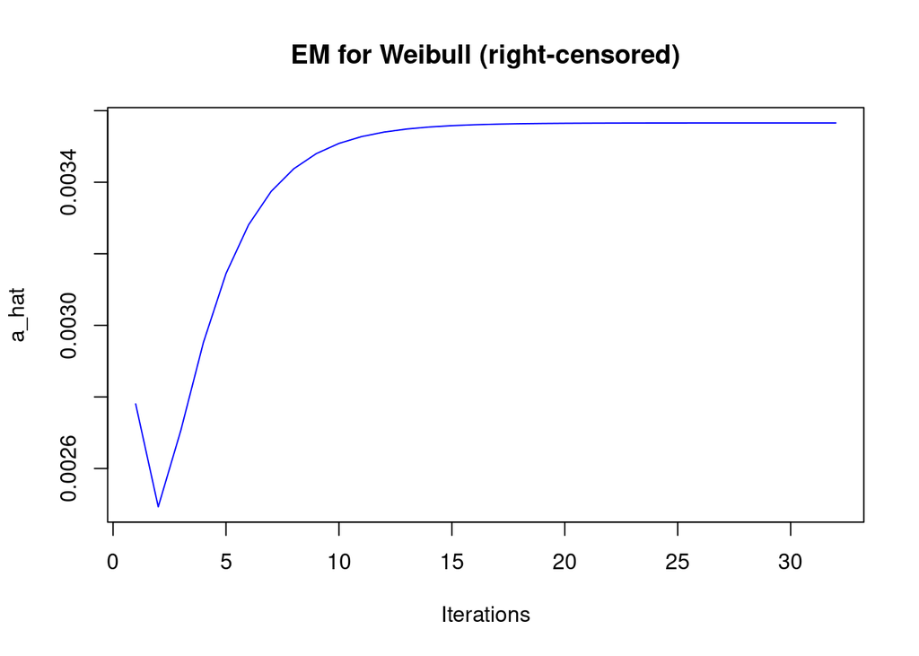

```r
# Vẽ đồ thị hội tụ
plot(1:result$iterations, result$param_history[, 1], type = "l", col = "blue",
     xlab = "Iterations", ylab = "a_hat", main = "EM for Weibull (right-censored)")
```

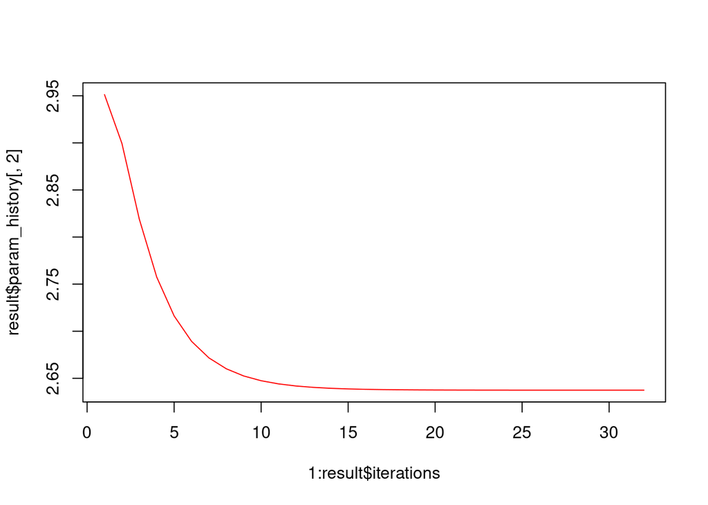

```r
plot(1:result$iterations, result$param_history[, 2], type = "l", col = "red")
```

#### c) So sánh kết quả với điểm bắt đầu $(a^{(0)} , b^{(0)} ) = (0.003, 2.5)$.

```r
theta_0 <- c(0.003, 2.5)
result <- em_weibull(data$data_lifetime, data$delta, a_init = theta_0[1], b_init = theta_0[2])
```

```
Iter  1: a=0.00562, b=2.32460, diff=1.754191e-01
Iter  2: a=0.00544, b=2.37613, diff=5.153314e-02
Iter  3: a=0.00488, b=2.44590, diff=6.976631e-02
Iter  4: a=0.00445, b=2.50273, diff=5.683491e-02
Iter  5: a=0.00415, b=2.54453, diff=4.179938e-02
Iter  6: a=0.00395, b=2.57409, diff=2.955957e-02
Iter  7: a=0.00382, b=2.59456, diff=2.047238e-02
Iter  8: a=0.00374, b=2.60856, diff=1.399740e-02
Iter  9: a=0.00368, b=2.61805, diff=9.490596e-03
Iter 10: a=0.00364, b=2.62445, diff=6.399456e-03
Iter 11: a=0.00362, b=2.62875, diff=4.299376e-03
Iter 12: a=0.00360, b=2.63163, diff=2.881477e-03
Iter 13: a=0.00359, b=2.63356, diff=1.928084e-03
Iter 14: a=0.00358, b=2.63484, diff=1.288761e-03
Iter 15: a=0.00358, b=2.63571, diff=8.608153e-04
Iter 16: a=0.00357, b=2.63628, diff=5.747010e-04
Iter 17: a=0.00357, b=2.63666, diff=3.835632e-04
Iter 18: a=0.00357, b=2.63692, diff=2.559415e-04
Iter 19: a=0.00357, b=2.63709, diff=1.707590e-04
Iter 20: a=0.00357, b=2.63720, diff=1.139164e-04
Iter 21: a=0.00357, b=2.63728, diff=7.599089e-05
Iter 22: a=0.00357, b=2.63733, diff=5.068960e-05
Iter 23: a=0.00357, b=2.63736, diff=3.381148e-05
Iter 24: a=0.00357, b=2.63739, diff=2.255286e-05
Iter 25: a=0.00357, b=2.63740, diff=1.504297e-05
Iter 26: a=0.00357, b=2.63741, diff=1.003372e-05
Iter 27: a=0.00357, b=2.63742, diff=6.692494e-06
Iter 28: a=0.00357, b=2.63742, diff=4.463879e-06
Iter 29: a=0.00357, b=2.63743, diff=2.977391e-06
Iter 30: a=0.00357, b=2.63743, diff=1.985905e-06
Iter 31: a=0.00357, b=2.63743, diff=1.324588e-06
Iter 32: a=0.00357, b=2.63743, diff=8.834920e-07
Hội tụ tại vòng lặp 32
```

```r
print(result$a_hat)
```

```
[1] 0.003565753
```

```r
print(result$b_hat)
```

```
[1] 2.63743
```

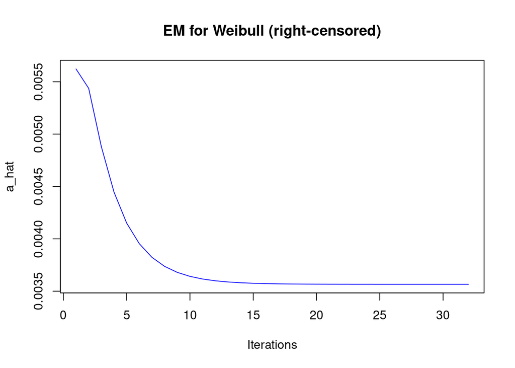

```r
# Vẽ đồ thị hội tụ
plot(1:result$iterations, result$param_history[, 1], type = "l", col = "blue",
     xlab = "Iterations", ylab = "a_hat", main = "EM for Weibull (right-censored)")
```

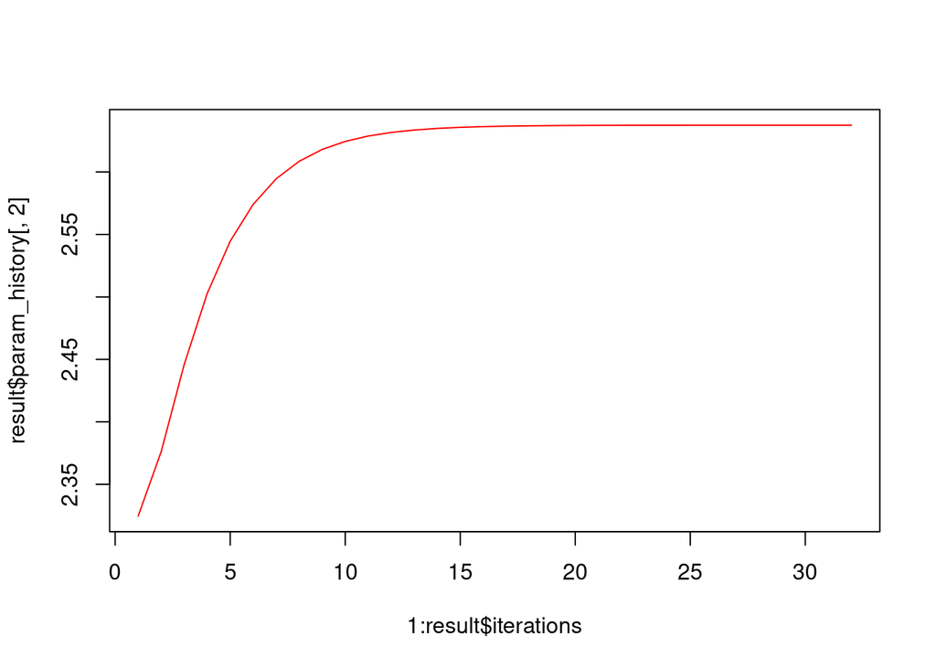

```r
plot(1:result$iterations, result$param_history[, 2], type = "l", col = "red")
```